# COMPSCIX 415.2 Homework 4

Elaine Phan

7/3/2018

1. Section 5.6.7: #2, #4 and #6 only. Extra Credit: Do #5 Brainstorm at least 5 different ways to assess the typical delay characteristics of a group of flights. Consider the following scenarios:
2. Come up with another approach that will give you the same output as not_cancelled %>% count(dest) and not_cancelled %>% count(tailnum, wt = distance) (without using count()). A. not_cancelled %>% count(dest) B. not_cancelled %>% count(tailnum, wt = distance)

```r
not_cancelled <- flights %>%
  filter(!is.na(dep_delay), !is.na(arr_delay))
#A.
not_cancelled %>% group_by(dest) %>% summarize(n = n())
```

```
## # A tibble: 104 x 2
##    dest      n
##    <chr> <int>
##  1 ABQ     254
##  2 ACK     264
##  3 ALB     418
##  4 ANC       8
##  5 ATL   16837
##  6 AUS    2411
##  7 AVL     261
##  8 BDL     412
##  9 BGR     358
## 10 BHM     269
## # ... with 94 more rows
```

```r
#B.
not_cancelled %>% group_by(tailnum) %>% summarize(n = sum(distance))
```

```
## # A tibble: 4,037 x 2
##    tailnum      n
##    <chr>    <dbl>
##  1 D942DN    3418
##  2 N0EGMQ  239143
##  3 N10156  109664
##  4 N102UW   25722
##  5 N103US   24619
##  6 N104UW   24616
##  7 N10575  139903
##  8 N105UW   23618
##  9 N107US   21677
## 10 N108UW   32070
## # ... with 4,027 more rows
```

4. A.Look at the number of cancelled flights per day. B.Is there a pattern? C.Is the proportion of cancelled flights related to the average delay?

```r
# A.
flights %>% filter(is.na(dep_delay) | is.na(arr_delay)) %>%
  group_by(month, day) %>% count(day)
```

```
## # A tibble: 363 x 3
## # Groups:   month, day [363]
##    month   day     n
##    <int> <int> <int>
##  1     1     1    11
##  2     1     2    15
##  3     1     3    14
##  4     1     4     7
##  5     1     5     3
##  6     1     6     3
##  7     1     7     3
##  8     1     8     7
##  9     1     9     9
## 10     1    10     3
## # ... with 353 more rows
```

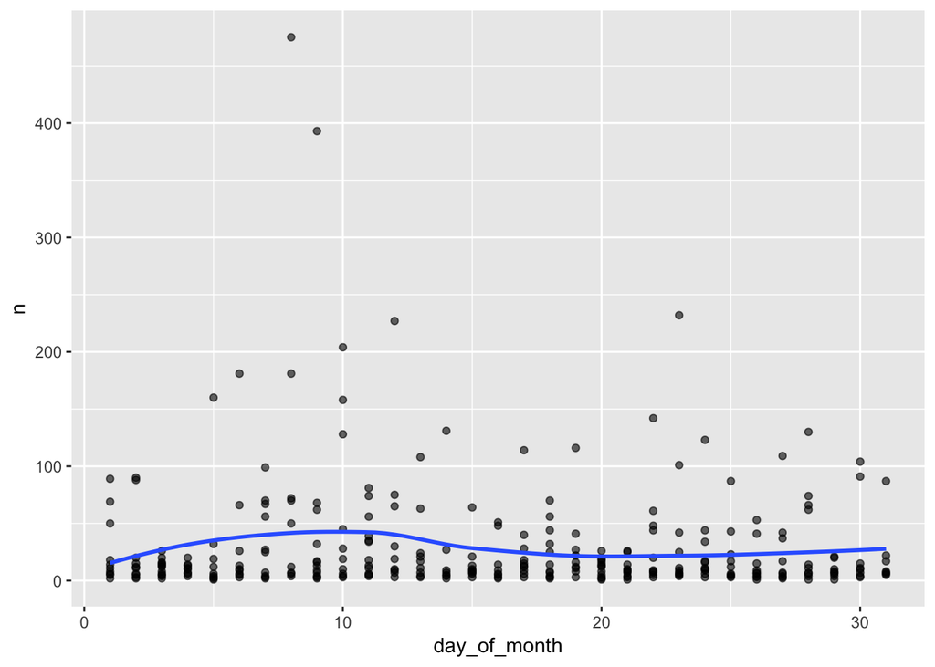

```r
day <- as.numeric(strftime(flights$time_hour, format = "%j"))

flights.1 <- flights %>%
  mutate(day_of_month = day)
cancelled <- flights.1 %>% filter(is.na(dep_delay) | is.na(arr_delay)) %>%
  add_count(month, day) %>% select(day_of_month, n) %>% distinct()
ggplot(cancelled, aes(x = day_of_month, y = n)) + geom_point(alpha = .6) +
  geom_smooth(span = .85, se = FALSE)
```

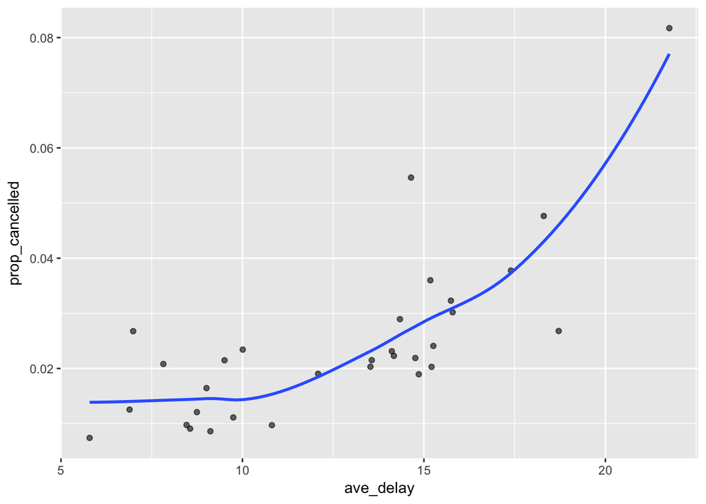

```r
#B. The pattern looks like there is more cancel flights around day 10 of the month.
#C.
summary <- flights.1 %>% group_by(day_of_month) %>%
  summarize(
    num_cancelled = sum(is.na(dep_delay) & is.na(arr_delay)),
    prop_cancelled = mean(is.na(dep_delay) & is.na(arr_delay)),
    ave_delay = mean(dep_delay, na.rm = TRUE)
  )

ggplot(summary, aes(x = ave_delay, y = prop_cancelled)) + geom_point(alpha = .6) +
  geom_smooth(se=FALSE)
```